# household members

# All household members

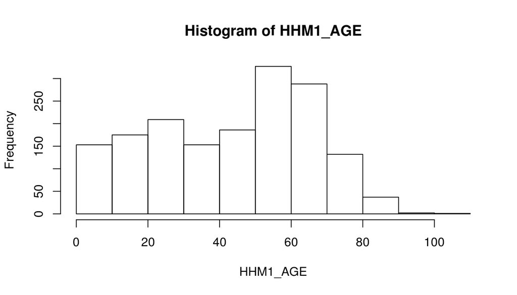

```r
# all HHM1 and HHM2 data
data_hhm <- data2 %>%
  select(c(374:375, 407:417, 405:406, 418:428))

# all ages histogram
with(data_hhm, hist(HHM1_AGE))
```

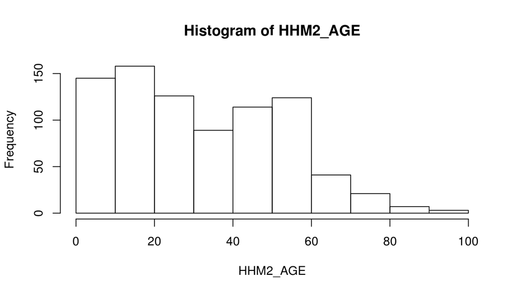

```r
with(data_hhm, hist(HHM2_AGE))
```

# Household children

- need to join hhm1 and hhm2 into single dataframe

```r
# subset children data
hhm_ch1 <- data2 %>%
  select(c(374:375, 407:417)) %>%
  filter(HHM1_AGE < 18)
hhm_ch2 <- data2 %>%
  select(c(405:406, 418:428)) %>%
  filter(HHM2_AGE < 18)

# distribution of age
with(hhm_ch1, table(HHM1_AGE))
```

```
## HHM1_AGE
##  0  1  2  3  4  5  6  7  8  9 10 11 12 13 14 15 16 17
##  9 21  8 11 15 14 12 15 14 14 20 18  8 15  9 16 27 24
```

```r
with(hhm_ch2, table(HHM2_AGE))
```

```
## HHM2_AGE
##  0  1  2  3  4  5  6  7  8  9 10 11 12 13 14 15 16 17
##  8 12  9 24 13 14 14 11 15 11 14 11 24 15 17 19 11 18
```

```r
# count total number of children >18 years
hhm_ch1 %>%
  group_by(HHM1_AGE) %>%
  summarise(n = n()) %>%
  summarise(sum(n))
```

```
## Source: local data frame [1 x 1]
##
##   sum(n)
##    <int>
## 1    270
```

```r
hhm_ch2 %>%
  group_by(HHM2_AGE) %>%
  summarise(n = n()) %>%
  summarise(sum(n))
```

```
## Source: local data frame [1 x 1]
##
##   sum(n)
##    <int>
## 1    260
```

Total number of children = 530

## HHM1: child 1

### Q35. What is the gender of this member of the household? Remember, this relates to HHM1_Name who is HHM1_AGE years old.

```r
with(hhm_ch1, table(Q35))
```

```
## Q35
## Female   Male
##    128    139
```

### Q36. On average, how many days per week does this member of your household work or attend day care or school outside of your home?

```r
with(hhm_ch1, summary(Q36))
```

```
##    Min. 1st Qu.  Median    Mean 3rd Qu.    Max.    NA's
##   0.000   3.000   5.000   3.778   5.000   7.000       9
```

### Q37. On average, how many days per week does this member of your household participate in social activities outside of your home?

```r
with(hhm_ch1, summary(Q37))
```

```
##    Min. 1st Qu.  Median    Mean 3rd Qu.    Max.    NA's
##   0.000   1.000   2.000   2.685   4.250   7.000      10
```

### Q38. On average, how many days per week does this member of your household use public transportation?

```r
with(hhm_ch1, summary(Q38))
```

```
##    Min. 1st Qu.  Median    Mean 3rd Qu.    Max.    NA's
##  0.0000  0.0000  0.0000  0.6692  0.0000  6.0000      10
```

### Q39. How frequently does this member of your household visit a doctor’s office for wellness appointments?

```r
with(hhm_ch1, table(Q39))
```

```
## Q39
## More than once per year           Once per year Less than once per year
##                      74                     160                      21
##                   Never              Don_t know
##                       6                       8
```

### Q40. How frequently does this member of the household get sick in a typical year?

```r
with(hhm_ch1, table(Q40))
```

```
## Q40
##         Never  1 to 2 times  3 to 5 times 6 to 10 times  More than 10
##            11           163            77             8             2
##    Don_t know
##             8
```

### Q41. How many times has this member of your household had influenza or another respiratory illness in the last two years?

```r
with(hhm_ch1, table(Q41))
```

```
## Q41
##       Never        Once     2 times     3 times More than 3  Don_t know
##         137          61          29          13          10          18
```

### Q42. Does this member of your household get an annual influenza vaccine?

```r
with(hhm_ch1, table(Q42))
```

```
## Q42
##    Yes, always Yes, sometimes      No, never     Don_t know
##            121             48             84             16
```

## HHM2: child 2

### Q43. What is the gender of this member of the household? Remember, this relates to HHM1_Name who is HHM1_AGE years old.

```r
with(hhm_ch2, table(Q43))
```

```
## Q43
## Female   Male
##    135    122
```

### Q44. On average, how many days per week does this member of your household work or attend day care or school outside of your home?

```r
with(hhm_ch2, summary(Q44))
```

```
##    Min. 1st Qu.  Median    Mean 3rd Qu.    Max.    NA's
##    0.00    4.00    5.00    3.94    5.00    7.00       9
```

### Q45. On average, how many days per week does this member of your household participate in social activities outside of your home?

```r
with(hhm_ch2, summary(Q45))
```

```
##    Min. 1st Qu.  Median    Mean 3rd Qu.    Max.    NA's
##     0.0     1.0     2.0     2.5     4.0     7.0      12
```

### Q46. On average, how many days per week does this member of your household use public transportation?

```r
with(hhm_ch2, summary(Q46))
```

```
##    Min. 1st Qu.  Median    Mean 3rd Qu.    Max.    NA's
##  0.0000  0.0000  0.0000  0.9271  0.0000  6.0000      13
```

### Q47. How frequently does this member of your household visit a doctor’s office for wellness appointments?

```r
with(hhm_ch2, table(Q47))
```

```
## Q47
## More than once per year           Once per year Less than once per year
##                      68                     150                      22
##                   Never              Don_t know
##                       9                       9
```

### Q48. How frequently does this member of the household get sick in a typical year?

```r
with(hhm_ch2, table(Q48))
```

```
## Q48
##         Never  1 to 2 times  3 to 5 times 6 to 10 times  More than 10
##            17           154            65            10             2
##    Don_t know
##            10
```

### Q49. How many times has this member of your household had influenza or another respiratory illness in the last two years?

```r
with(hhm_ch2, table(Q49))
```

```
## Q49
##       Never        Once     2 times     3 times More than 3  Don_t know
##         124          65          35           9           8          17
```

### Q50. Does this member of your household get an annual influenza vaccine?

```r
with(hhm_ch2, table(Q50))
```

```
## Q50
##    Yes, always Yes, sometimes      No, never     Don_t know
##            104             49             89             17
```